# Gradient Descent

# Gradient Descent

Follow gradient descent on smooth objectives and apply it to image restoration. Changing the step size reveals the relationship between curvature, stability, and the speed at which the objective decreases.

## Run this tour

Run the cells in order with a Python 3 kernel. The first cell locates the companion data and toolbox and installs missing dependencies when needed. All worked examples include their implementation directly in this notebook. Random seeds make comparisons reproducible; you can change them to explore other samples.

```python
# Locate the companion toolbox locally, or fetch it for a standalone/Colab copy.
from pathlib import Path
import importlib.util
import os
import subprocess
import sys

working = Path.cwd()
candidates = [working, working / "python", working.parent / "python"]
python_dir = next((p for p in candidates if (p / "nt_toolbox").is_dir()), None)
if python_dir is None:
    checkout = working / "numerical-tours-support"
    if not checkout.exists():
        subprocess.run(
            [
                "git",
                "clone",
                "--depth",
                "1",
                "--branch",
                "master",
                "https://github.com/gpeyre/numerical-tours.git",
                str(checkout),
            ],
            check=True,
        )
    python_dir = checkout / "python"
os.chdir(python_dir)
if str(python_dir) not in sys.path:
    sys.path.insert(0, str(python_dir))
requirements = python_dir / "requirements.txt"
if any(
    importlib.util.find_spec(name) is None
    for name in [
        "numpy",
        "scipy",
        "matplotlib",
        "skimage",
        "sklearn",
        "pywt",
        "ipywidgets",
        "cvxpy",
        "skfmm",
        "autograd",
        "progressbar",
        "celer",
    ]
):
    subprocess.run(
        [sys.executable, "-m", "pip", "install", "-r", str(requirements)], check=True
    )

import numpy as np
import matplotlib.pyplot as plt

np.random.seed(0)
plt.rcParams.update(
    {
        "figure.figsize": (8, 4),
        "figure.dpi": 100,
        "axes.spines.top": False,
        "axes.spines.right": False,
        "font.size": 11,
        "image.cmap": "gray",
    }
)
%matplotlib inline
```

This tour explores the use of gradient descent method for unconstrained and constrained optimization of a smooth function

$\newcommand{\dotp}[2]{\langle #1, #2 \rangle}$ $\newcommand{\pd}[2]{ \frac{ \partial #1}{\partial #2} }$ $\newcommand{\umin}[1]{\underset{#1}{\min}\;}$ $\newcommand{\qandq}{\quad\text{and}\quad}$ $\newcommand{\qwhereq}{\quad\text{where}\quad}$ $\newcommand{\qifq}{ \quad \text{if} \quad }$ $\newcommand{\ZZ}{\mathbb{Z}}$ $\newcommand{\RR}{\mathbb{R}}$ $\newcommand{\pa}[1]{\left(#1\right)}$ $\newcommand{\si}{\sigma}$ $\newcommand{\Nn}{\mathcal{N}}$ $\newcommand{\Hh}{\mathcal{H}}$ $\newcommand{\Bb}{\mathcal{B}}$ $\newcommand{\EE}{\mathbb{E}}$ $\newcommand{\norm}[1]{\|#1\|}$ $\newcommand{\abs}[1]{\left|#1\right|}$ $\newcommand{\choice}[1]{ \left\{ \begin{array}{l} #1 \end{array} \right. }$ $\newcommand{\al}{\alpha}$ $\newcommand{\la}{\lambda}$ $\newcommand{\ga}{\gamma}$ $\newcommand{\Ga}{\Gamma}$ $\newcommand{\La}{\Lambda}$ $\newcommand{\Si}{\Sigma}$ $\newcommand{\be}{\beta}$ $\newcommand{\de}{\delta}$ $\newcommand{\De}{\Delta}$ $\newcommand{\phi}{\varphi}$ $\newcommand{\th}{\theta}$ $\newcommand{\om}{\omega}$ $\newcommand{\Om}{\Omega}$

```python
%matplotlib inline
import numpy as np
import matplotlib.pyplot as plt
```

## Gradient Descent for Unconstrained Problems

We consider the problem of finding a minimum of a function $f$, hence solving $$\umin{x \in \RR^d} f(x)$$ where $f : \RR^d \rightarrow \RR$ is a smooth function.

Note that the minimum is not necessarily unique. In the general case, $f$ might exhibit local minima, in which case the proposed algorithms is not expected to find a global minimizer of the problem. In this tour, we restrict our attention to convex function, so that the methods will converge to a global minimizer.

The simplest method is the gradient descent, that computes $$ x^{(k+1)} = x^{(k)} - \tau_k \nabla f(x^{(k)}), $$ where $\tau_k>0$ is a step size, and $\nabla f(x) \in \RR^d$ is the gradient of $f$ at the point $x$, and $x^{(0)} \in \RR^d$ is any initial point.

In the convex case, if $f$ is of class $C^2$, in order to ensure convergence, the step size should satisfy $$ 0 < \tau_k < \frac{2}{ \sup_x \norm{Hf(x)} } $$ where $Hf(x) \in \RR^{d \times d}$ is the Hessian of $f$ at $x$ and $\norm{\cdot}$ is the spectral operator norm (largest eigenvalue).

## Gradient Descent in 2-D

We consider a simple problem, corresponding to the minimization of a 2-D quadratic form $$ f(x) = \frac{1}{2} \pa{ x_1^2 + \eta x_2^2 } ,$$ where $\eta>0$ controls the anisotropy, and hence the difficulty, of the problem.

Anisotropy parameter $\eta$.

```python
eta = 4
```

Function $f$.

```python
f = lambda x: (x[0] ** 2 + eta * x[1] ** 2) / 2
```

Background image of the function.

```python
tx = np.linspace(-0.3, 1, 101)
ty = np.linspace(-0.6, 0.6, 101)
[v, u] = np.meshgrid(ty, tx)
F = (u**2 + eta * v**2) / 2
```

Display the function as a 2-D image.

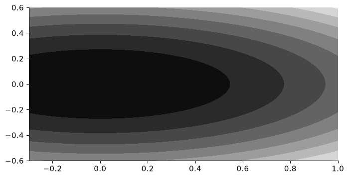

```python
plt.contourf(tx, ty, F.transpose(), 10);
```

Gradient.

```python
Gradf = lambda x: np.array([x[0], eta * x[1]])
```

The step size should satisfy $\tau_k < 2/\eta$. We use here a constant step size.

```python
tau = 1.6 / eta
```

Initial point for the descent.

```python
x0 = np.array([0.9, 0.3])
```

**Exercice 1:**

Perform the gradient descent using a fixed step size $\tau_k=\tau$. Display the decay of the energy $f(x^{(k)})$ through the iteration. Save the iterates so that X(:,k) corresponds to $x^{(k)}$.

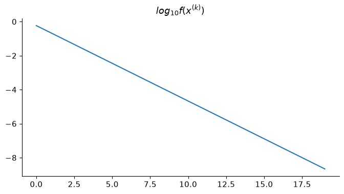

```python
x = x0
niter = 20
E = np.zeros((niter, 1))
X = np.zeros((2, niter))
for i in np.arange(0, niter):
    X[:, i] = x
    E[i] = f(x)
    x = x - tau * Gradf(x)

plt.clf()
h = plt.plot(np.log10(E))
plt.axis("tight")
plt.title("$log_{10}f(x^{(k)})$")
```

Display the iterations.

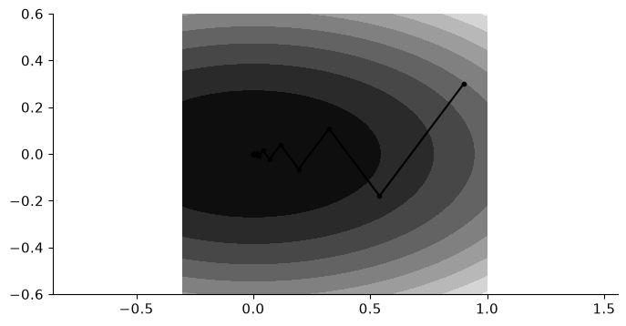

```python
plt.contourf(tx, ty, F.transpose(), 10)
plt.plot(X[0, :], X[1, :], "k.-")
plt.axis("equal");
```

**Exercice 2:**

Display the iteration for several different step sizes.

```
(np.float64(-0.3), np.float64(1.0), np.float64(-0.6), np.float64(0.6))
```

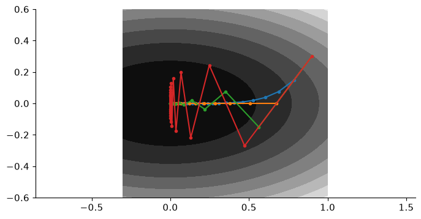

```python
niter = 20

plt.clf()
plt.contourf(tx, ty, F.transpose(), 10)
tau_list = np.array([0.5, 1, 1.5, 1.9]) / eta

for itau in np.arange(0, tau_list.size):
    tau = tau_list[itau]
    x = x0
    X = np.zeros((2, niter))
    for i in np.arange(0, niter):
        X[:, i] = x.flatten()
        x = x - tau * Gradf(x)
    plt.plot(X[0, :], X[1, :], ".-")
plt.axis("equal")
```

**Exercice 3:**

Implement the optimal step size selection (exact linesearch).

```
(np.float64(-0.3), np.float64(1.0), np.float64(-0.6), np.float64(0.6))
```

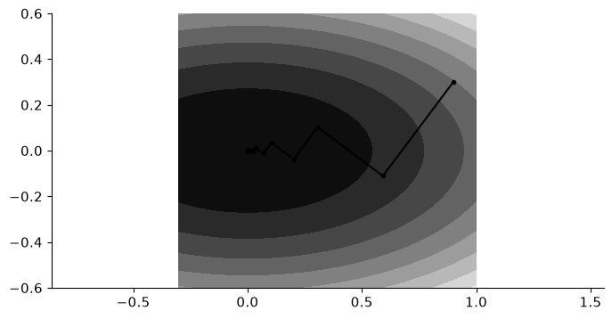

```python
niter = 20

x = x0

X = np.zeros((2, niter))
for i in np.arange(0, niter):
    X[:, i] = x.flatten()
    # optimal step size
    tau = (x[0] ** 2 + eta**2 * x[1] ** 2) / (x[0] ** 2 + eta**3 * x[1] ** 2)
    x = x - tau * Gradf(x)


plt.clf()
plt.contourf(tx, ty, F.transpose(), 10)
plt.plot(X[0, :], X[1, :], "k.-")
plt.axis("equal")
```

## Gradient and Divergence of Images

Local differential operators like gradient, divergence and laplacian are the building blocks for variational image processing.

Load an image $x_0 \in \RR^N$ of $N=n \times n$ pixels.

```python
from nt_toolbox.general import clamp, np, plt
from nt_toolbox.signal import div, grad, imageplot, load_image, np, plt
import numpy as np
import matplotlib.pyplot as plt
from numpy import (
    abs,
    concatenate,
    equal,
    linspace,
    maximum,
    meshgrid,
    newaxis,
    ones,
    r_,
    size,
    sqrt,
    sum,
    tile,
)
from matplotlib.pyplot import axis, matplotlib, np, step
from numpy.linalg import norm
from numpy.random import randn
```

```python
n = 256
name = "nt_toolbox/data/lena.png"
x0 = load_image(name, n)
```

Display it.

[figure not shown]

```python
imageplot(x0)
```

We discretize this differential operator on a discrete image $x \in \RR^N$ using first order finite differences. $$(\nabla x)_i = ( x_{i_1,i_2}-x_{i_1-1,i_2}, x_{i_1,i_2}-x_{i_1,i_2-1} ) \in \RR^2.$$ Note that for simplity we use periodic boundary conditions.

Compute its gradient, using finite differences.

```python
def grad(x):
    hdiff = x - x[r_[len(x) - 1, : len(x) - 1], :]
    vdiff = x - x[:, r_[len(x) - 1, : len(x) - 1]]
    return concatenate((hdiff[..., newaxis], vdiff[..., newaxis]), axis=2)
```

One thus has $\nabla : \RR^N \mapsto \RR^{N \times 2}.$

```python
v = grad(x0)
```

One can display each of its components.

[figure not shown]

```python
imageplot(v[:, :, 0], "d/dx", (1, 2, 1))
imageplot(v[:, :, 1], "d/dy", (1, 2, 2))
```

One can display its magnitude $\norm{(\nabla x)_i}$, which is large near edges.

[figure not shown]

```python
imageplot(sqrt(sum(v * v, axis=2)))
```

The divergence operator maps vector field to images. For continuous vector fields (v(s) \in \RR^2), it is defined as $$\text{div}(v)(s) = \pd{v_1(s)}{s_1} + \pd{v_2(s)}{s_2} \in \RR.$$ (note that here, the variable (s) denotes the 2-D spacial position). It is minus the adjoint of the gadient, i.e. $\text{div} = - \nabla^*$.

It is discretized, for $v=(v^1,v^2)$ as $$\text{div}(v)_i = v^1_{i_1+1,i_2} - v^1_{i_1,i_2} + v^2_{i_1,i_2+1} - v^2_{i_1,i_2} .$$

```python
div = lambda x: (
    x[r_[1 : len(x), 0], :, 0] - x[:, :, 0] + x[:, r_[1 : len(x), 0], 1] - x[:, :, 1]
)
```

The Laplacian operatore is defined as $\Delta=\text{div} \circ \nabla = -\nabla^* \circ \nabla$. It is thus a negative symmetric operator.

```python
delta = lambda x: div(grad(x))
```

Display $\Delta x_0$.

[figure not shown]

```python
imageplot(delta(x0))
```

Check that the relation $\norm{\nabla x} = - \dotp{\Delta x}{x}.$

```python
print("Should be 0:\n", (grad(x0) * grad(x0)).sum() + (delta(x0) * x0).sum())
```

```
Should be 0:
 0.0
```

## Gradient Descent in Image Processing

We consider now the problem of denoising an image $y \in \RR^d$ where $d = n \times n$ is the number of pixels ($n$ being the number of rows/columns in the image).

Add noise to the original image, to simulate a noisy image.

```python
sigma = 0.1
y = x0 + sigma * randn(n, n)
```

Display the noisy image $y$.

[figure not shown]

```python
imageplot(clamp(y))
```

Denoising is obtained by minimizing the following functional $$\umin{x \in \RR^d} f(x) = \frac{1}{2} \norm{y-x}^2 + \la J_\epsilon(x)$$ where $J_\epsilon(x)$ is a smoothed total variation of the image. $$J_\epsilon(x) = \sum_i \norm{ (G x)_i }_{\epsilon}$$ where $(Gx)_i \in \RR^2$ is an approximation of the gradient of $x$ at pixel $i$ and for $u \in \RR^2$, we use the following smoothing of the $L^2$ norm in $\RR^2$ $$\norm{u}_\epsilon = \sqrt{ \epsilon^2 + \norm{u}^2 },$$ for a small value of $\epsilon>0$.

The gradient of the functional read $$\nabla f(x) = x-y + \lambda \nabla J_\epsilon(x)$$ where the gradient of the smoothed TV norm is $$\nabla J_\epsilon(x)_i = G^*( u ) \qwhereq u_i = \frac{ (G x)_i }{\norm{ (G x)_i }_\epsilon} $$ where $G^*$ is the adjoint operator of $G$ which corresponds to minus a discretized divergence

Value for $\lambda$.

```python
la = 0.3 / 5
```

Value for $\epsilon$.

```python
epsilon = 1e-3
```

TV norm.

```python
norm_eps = lambda u: sqrt(epsilon**2 + sum(u * u, axis=2))
J = lambda x: sum(sum(norm_eps(grad(x))))
```

Function $f$ to minimize.

```python
f = lambda x: 1 / 2 * norm(x - y) ** 2 + la * J(x)
```

Gradient of $J_\epsilon$. Note that |div| implement $-G^*$.

```python
normalize_vec = lambda u: u / tile(norm_eps(u)[..., newaxis], (1, 1, 2))
gradTV = lambda x: -div(normalize_vec(grad(x)))
```

Gradient of the functional.

```python
Gradf = lambda x: x - y + la * gradTV(x)
```

```python
tau = 1.8 / (1 + la * 8 / epsilon)
tau = tau * 4
```

```python
# imageplot(clamp(x))
```

## Constrained Optimization Using Projected Gradient Descent

We consider a linear imaging operator $\Phi : x \mapsto \Phi(x)$ that maps high resolution images to low dimensional observations. Here we consider a pixel masking operator, that is diagonal over the spacial domain.

To emphasis the effect of the TV functional, we use a simple geometric image.

```python
n = 64
radius = 0.6
t = linspace(-1, 1, n)
[Y, X] = meshgrid(t, t)
x0 = (maximum(abs(X), abs(Y)) < radius) * 1.0
```

We consider here the inpainting problem. This simply corresponds to a masking operator. Here we remove the central part of the image.

```python
a = 4
Lambda = ones((n, n))
Lambda[n // 2 - a : n // 2 + a, :] = 0
```

Masking operator $\Phi$. Note that it is symmetric, i.e. $\Phi^*=\Phi$.

```python
Phi = lambda x: x * Lambda
PhiS = Phi
```

Noiseless observations $y=\Phi x_0$.

```python
y = Phi(x0)
```

Display.

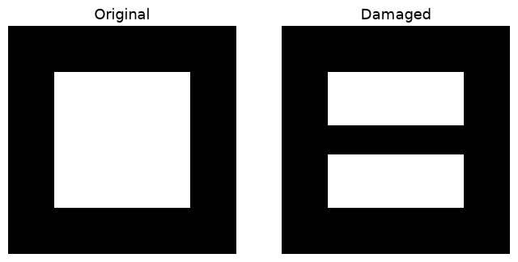

```python
imageplot(x0, "Original", (1, 2, 1))
imageplot(y, "Damaged", (1, 2, 2))
```

We want to solve the noiseless inverse problem $y=\Phi f$ using a total variation regularization: $$\umin{ y=\Phi x } J_\epsilon(x).$$ We use the following projected gradient descent $$x^{(k+1)} = \text{Proj}_{\Hh}( x^{(k)} - \tau_k \nabla J_{\epsilon}(x^{(k)}) )$$ where $\text{Proj}_{\Hh}$ is the orthogonal projection on the set of linear constraint $\Phi x = y$, and is easy to compute for inpainting

```python
ProjH = lambda x: x + PhiS(y - Phi(x))
```

*Exercice 5:* Try with several values of $\epsilon$.

## References and further reading

- Stephen Boyd and Lieven Vandenberghe. [Convex Optimization](https://web.stanford.edu/~boyd/cvxbook/). 2004, Cambridge University Press. Convexity, duality, optimality conditions, and interior-point methods.
- Neal Parikh and Stephen Boyd. [Proximal Algorithms](https://web.stanford.edu/~boyd/papers/prox_algs.html). 2014, Foundations and Trends in Optimization 1(3), 127–239. Proximity operators and splitting methods for nonsmooth objectives.
- Amir Beck and Marc Teboulle. [A Fast Iterative Shrinkage-Thresholding Algorithm for Linear Inverse Problems](https://doi.org/10.1137/080716542). 2009, SIAM Journal on Imaging Sciences 2(1), 183–202. Accelerated proximal gradient descent and its convergence rate.
- Antonin Chambolle and Thomas Pock. [A First-Order Primal-Dual Algorithm for Convex Problems with Applications to Imaging](https://doi.org/10.1007/s10851-010-0251-1). 2011, Journal of Mathematical Imaging and Vision 40, 120–145. Primal–dual splitting for total variation and other composite penalties.
- Laurent Condat. [A Primal–Dual Splitting Method for Convex Optimization Involving Lipschitzian, Proximable and Linear Composite Terms](https://doi.org/10.1007/s10957-012-0245-9). 2013, Journal of Optimization Theory and Applications 158, 460–479. Step-size conditions and a general primal–dual framework.